# Homework 2

Alp Serdaroğlu

11/22/2021

# Introduction

```r
setwd("C:/Users/alpsr/Desktop/IE 48B Assignment 2/CBF")
library(data.table)
library(ggplot2)
library(genlasso)
library(rpart)
library(rattle)

WidetoLong <- function(x){
  long_x <- melt(x, id.vars = c('ID', 'Class'))
  return(long_x)
}
```

Cylinder-Bell-Funnel data set consists of 30 time series which are classified into three different classes, cylinder, bell and funnel. Our aim is to create a time series representation that will be used in time series classification setting. In this analysis, one dimensional fused lasso method and piecewise adaptive constant approximations using regression trees will be used. Then, the mean squared errors of the two methods will be compared and their performance in classifying the time series in the training data set will be evaluated.

In the first part of our analysis, data is imported and manipulated into desired format. The structure of the CBF dataset is as follows.

```r
setwd("C:/Users/alpsr/Desktop/IE 48B Assignment 2/CBF")
raw_data <- read.table("CBF_Train.txt", header = F ,
                       na.strings ="", stringsAsFactors= F)
raw_data <- setnames(raw_data, "V1", "Class")
raw_data <- data.table(raw_data)
raw_data[, "ID" := 1:.N]

setcolorder(raw_data, c("ID", "Class"))
cbf <- raw_data
cbf_long <- WidetoLong(raw_data)
cbf_long[,variable := as.numeric(gsub('V','',variable))-1]

head(round(cbf,2))
```

```
##    ID Class    V2    V3    V4    V5    V6    V7    V8    V9   V10   V11   V12
## 1:  1     1 -0.46 -0.56 -0.84 -0.87 -0.94 -0.82 -0.26 -1.26 -1.25 -0.92 -0.92
## 2:  2     1 -0.90 -0.69 -1.35 -1.46 -1.17 -1.40 -1.82 -0.83 -1.02 -0.80 -1.26
## 3:  3     1 -0.46 -0.57 -0.03 -0.64 -0.60 -0.27 -0.27 -0.93 -0.45 -0.72 -0.40
## 4:  4     3 -0.19 -0.62 -0.82 -0.52 -0.79 -0.97 -1.49 -0.28 -0.84  0.05 -0.81
## 5:  5     2 -1.14 -1.32 -1.84 -0.79 -0.25 -1.49 -0.67 -0.34 -1.05 -0.31 -1.03
## 6:  6     2 -0.57 -0.89 -0.05 -0.04 -0.48 -1.09 -0.95 -0.03 -0.80 -0.51 -0.72
##      V13   V14   V15   V16   V17   V18   V19   V20   V21   V22   V23   V24
## 1: -0.98 -1.29 -1.14 -1.05 -0.37 -0.69 -0.98 -0.99 -0.89 -1.11 -0.77 -1.01
## 2: -1.14 -0.88 -1.55 -0.92 -1.40  0.78  1.10  1.19  0.38  0.95  0.80  1.16
## 3: -0.96 -1.42 -0.78 -0.46 -1.18 -0.50 -0.58 -0.58 -0.92 -0.72 -0.55 -0.99
## 4: -1.23 -0.67 -0.78  0.06 -1.25 -0.79 -0.93 -1.09 -0.61 -0.70  0.02  2.98
## 5: -1.20 -0.65 -1.62 -0.41 -1.05 -1.18 -0.43 -1.20 -0.59 -1.17 -0.32 -1.71
## 6: -0.52 -1.07 -0.43 -0.70  0.08 -0.18 -0.41 -1.25  0.63  0.11 -0.40  0.30
##      V25   V26   V27   V28   V29   V30   V31   V32   V33   V34   V35   V36
```

[output cut: 62 more lines]

### Class 1: Cylinder

The data set contains three different classes. First of the classes is cylinder. One instance of this class is displayed below.

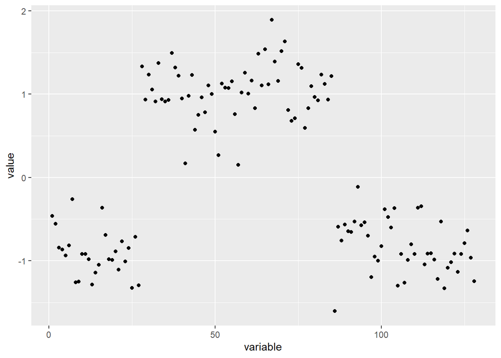

```r
ggplot(cbf_long[ID == 1])+
  geom_point(aes(x = variable, y = value))
```

### Class 2: Bell

Second class is the bell class which displays a steady increase before a sudden decrease late in the series as displayed below.

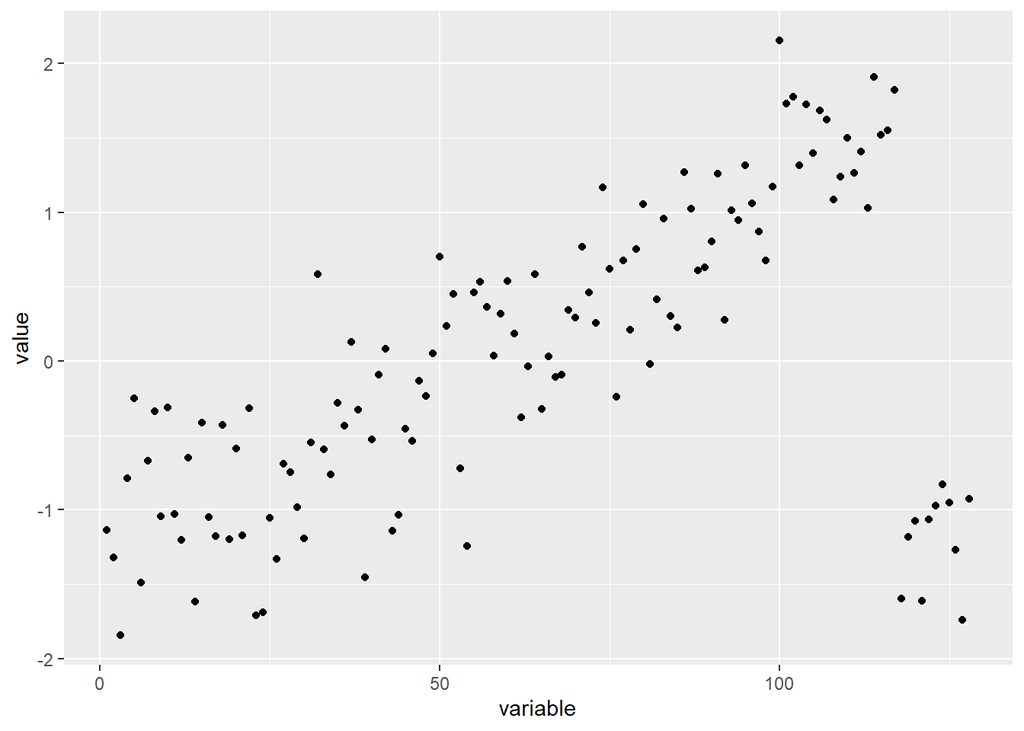

```r
ggplot(cbf_long[ID == 5])+
  geom_point(aes(x = variable, y = value))
```

### Class 3: Funnel

The last class is the funnel class which displays a sudden increase early in the series which is followed by a steady decrease as displayed below.

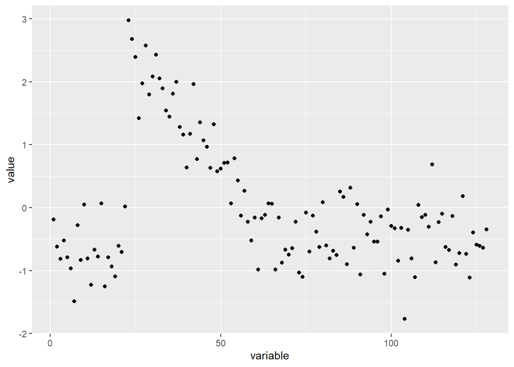

```r
ggplot(cbf_long[ID == 4])+
  geom_point(aes(x = variable, y = value))
```

# Tasks 1 & 2 - Time Series Representations

In this part of the analysis, two different representations of the CBF data set are created. 1D-Fused Lasso method is used to create the first representation whereas the second representation is created using the regression trees.

## Task 1 - 1D Fused Lasso

For this task genlasso package in R is used to perform the representation. For each series, a representation is calculated using different values of lambda. Lambda parameter in the 1D Fused Lasso is the penalty assigned to the difference between two consecutive points of the representation. Thus, this method aims to achieve a representation in which the changes between the consecutive representation values are as small as possible.

To determine the best value for the lambda for each series, several observations are removed from the series as the test set. Then, the model is fitted on the remaining values and tested on the remaining points. For this analysis, every 10 points is removed from the observation. Then the model is fitted and tested for different lambda values. This procedure is repeated for 10 different sets of test points. This is acheieved by using the trendfilter and cv.trendfilter functions in the genlasso package. Other than the genlasso package two R functions created to run 1D Fused Lasso for a given series ID and k value (10 in our case).

The best lambda values for each time series are given below.

```r
setwd("C:/Users/alpsr/Desktop/IE 48B Assignment 2/CBF")
load("Workspace_Assignment_2.RData")
lasso[[1]]
```

```
##  [1] 0.7435113 0.6212955 0.6623808 1.3088513 1.0216196 1.0106194 1.4181884
##  [8] 1.1930381 1.0120080 0.1519257 0.9873853 0.8361207 0.8693928 0.8146329
## [15] 1.0462665 0.9764708 0.5506219 1.1111808 0.9706832 0.3620265 0.9586536
## [22] 0.5882071 0.7744089 1.2008345 1.1088469 0.8254610 1.0817774 1.3717851
## [29] 1.2658569 0.5448199
```

```r
FusedLasso1D <- function(dataset, id){

  # Getting the time series
  trial = dataset[id,c(-1,-2)]
  trial
  out = trendfilter(unlist(trial), ord = 0)
  cv = cv.trendfilter(out, k = 10, verbose = FALSE)

  minlambda = cv$lambda.min
  minlambdaindex = which(out$lambda == cv$lambda.min)
  fitted = out$fit[,minlambdaindex]

  ret <- list(minlambda, fitted)

  return(ret)
}

RunFusedLasso1D <- function(dataset, k){


  FittedValues <- data.table()
  Lambda <- 0

  for(i in seq(1,30)){

    out <- 0
    out <- FusedLasso1D(dataset,i)

    FittedValues <- rbind(FittedValues, t(unlist(out[2])))
    Lambda[i] <- unlist(out[1])

  }

  ret <- list(Lambda, FittedValues)

  return(ret)

}

lasso <- RunFusedLasso1D(cbf, 10)
lasso[[1]]
```

An example plot of the real time series and fitted model is as follows.

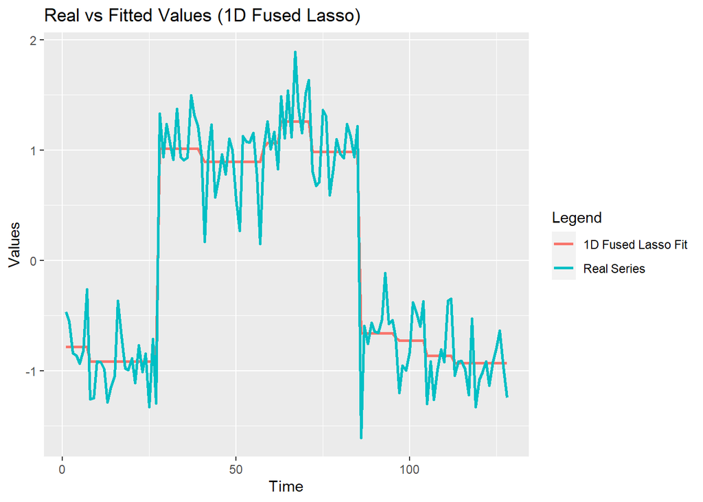

```r
plot_real <- unlist(cbf[1,-c("ID","Class")])
plot_fit_lasso <- unlist(lasso[[2]][1,])
plot_lasso <- data.frame(seq(1,128),plot_fit_lasso, plot_real)

ggplot(plot_lasso)+
  geom_line(aes(x = seq.1..128., y = plot_fit_lasso, color = '1D Fused Lasso Fit'), size = 1)+
  geom_line(aes(x = seq.1..128., y = plot_real, color = 'Real Series'), size = 1)+
  labs(x = 'Time', y = 'Values', title = 'Real vs Fitted Values (1D Fused Lasso)', colour = 'Legend')
```

```r
head(lasso[[2]])
```

```
##            V1         V2         V3         V4         V5         V6         V7
## 1: -0.7841218 -0.7841218 -0.7841218 -0.7841218 -0.7841218 -0.7841218 -0.7841218
## 2: -1.1019766 -1.1019766 -1.1917064 -1.1917064 -1.1917064 -1.1917064 -1.1917064
## 3: -0.4998039 -0.4998039 -0.4998039 -0.4998039 -0.4998039 -0.4998039 -0.4998039
## 4: -0.6648492 -0.6648492 -0.6648492 -0.6648492 -0.6648492 -0.6648492 -0.6648492
## 5: -1.0927387 -1.0927387 -1.0927387 -0.9361692 -0.9361692 -0.9361692 -0.9361692
## 6: -0.5232505 -0.5232505 -0.5232505 -0.5232505 -0.5232505 -0.5232505 -0.5232505
##            V8         V9        V10        V11        V12        V13        V14
## 1: -0.9158363 -0.9158363 -0.9158363 -0.9158363 -0.9158363 -0.9158363 -0.9158363
## 2: -1.0885778 -1.0885778 -1.0885778 -1.0885778 -1.0885778 -1.0885778 -1.0885778
## 3: -0.6247595 -0.6247595 -0.6247595 -0.6247595 -0.6960150 -0.6960150 -0.6960150
## 4: -0.6648492 -0.6648492 -0.6648492 -0.6648492 -0.6648492 -0.6648492 -0.6648492
## 5: -0.9361692 -0.9361692 -0.9361692 -0.9361692 -0.9361692 -0.9361692 -0.9361692
## 6: -0.5232505 -0.5232505 -0.5232505 -0.5232505 -0.5232505 -0.5232505 -0.5232505
##           V15        V16        V17        V18        V19        V20        V21
```

[output cut: 118 more lines]

## Task 2 - Regression Trees

The second representation method used in this analysis is the Regression Trees. In this method, the data is recursively divided into “leaves” whose means minimized the overall sum of squared errors. Complexity of the regression tree represenation are controlled using several different parameters such as minimum number of points in a node, minimum number of points in a node to be considered for a split, complexity parameter and maximum depth of the tree. For this analysis, minbucket is set to 10 and minsplit is set to 20. Also, complexity parameter is set to zero. Only remaining parameter value to be decided is the maximum depth of the tree. In this analysis, maximum depths of 1, 2, 3, and 4 are considered for each series.

This procedure produced the best maximum depths for 30 time series.

```r
regtree[[1]]
```

```
##  [1] 3 2 2 3 4 4 2 4 4 2 3 4 4 4 4 4 4 4 3 3 3 4 4 1 4 4 3 4 4 2
```

```r
RegressionTrees <- function(dataset, id, k){

  series <- dataset[ID == id,]

  # Forming the test indices
  test_index = seq(1,120, by = k)
  remove_index = -test_index # Indices to be removed

  error <- Matrix(0,nrow = 10, ncol = 4)

  for(i in seq(1,10)){
    for(j in c(1,2,3,4)){
      train = series[remove_index,] # Training Series
      fit <- rpart(value~variable, train, control = rpart.control(cp = 0, minsplit = 20, minbucket = 10, maxdepth = j))
      series[, predict := predict(fit, series)]
      error[i,j] <- sum(series[variable %in% test_index,(value-predict)^2])
    }
    test_index = test_index + 1
    remove_index = -test_index
  }

  depth = colSums(error)
  final_fit = rpart(value~variable, series, control = rpart.control(cp = 0, minsplit = 20, minbucket = 10, maxdepth = which.min(depth)))

  return(list(error,depth,which.min(depth),predict(final_fit,series)))
}


RunRegressionTrees <- function(dataset, k){

  BestDepth <- 0
  Fitted <- matrix(,nrow = 30, ncol = 128)
  Errors <- matrix(,nrow = 30, ncol = 4)
  for(i in seq(1,30)){
    fit <- RegressionTrees(dataset,i,k)
    BestDepth[i] <- unlist(fit[3])
    Fitted[i,] <- unlist(fit[4]) #rbind(Fitted, (unlist(fit[3])))
    Errors[i,] <- unlist(fit[2]) #rbind(Errors, (unlist(fit[2])))
  }
  return(list(BestDepth, Fitted, Errors))
}

regtree <- RunRegressionTrees(cbf_long, 10)
regtree[[1]]
```

An example plot of the real time series and fitted model is as follows.

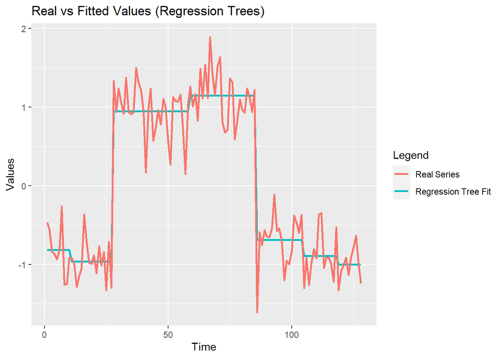

```r
plot_real <- unlist(cbf[1,-c("ID","Class")])
plot_fit_tree <- unlist(regtree[[2]][1,])
plot_tree <- data.frame(seq(1,128),plot_fit_tree, plot_real)

ggplot(plot_tree)+
  geom_line(aes(x = seq.1..128., y = plot_fit_tree, color = 'Regression Tree Fit'), size = 1)+
  geom_line(aes(x = seq.1..128., y = plot_real, color = 'Real Series'), size = 1)+
  labs(x = 'Time', y = 'Values', title = 'Real vs Fitted Values (Regression Trees)', colour = 'Legend')
```

Finally, as an example, representation obtained for the time series with ID = 1 is as follows.

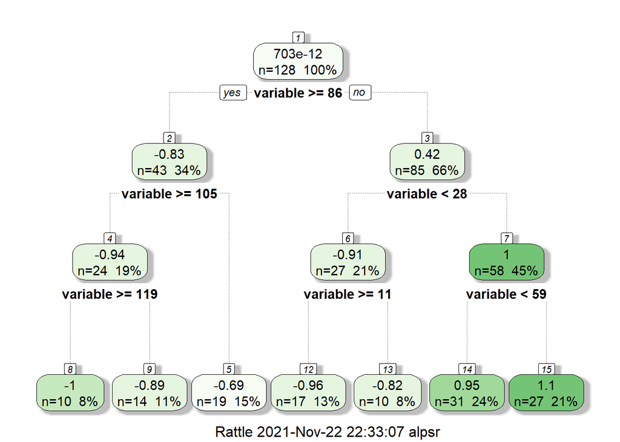

```r
example <- rpart(value~variable, cbf_long[ID == 1,], control = rpart.control(cp = 0, minsplit = 20, minbucket = 10, maxdepth = 3))
fancyRpartPlot(example)
```

# Task 3 - Comparing Mean Square Errors

In this part of our analysis, mean square errors of the two representation are compared with each other. To achieve this, each fitted model is compared with the original series both for 1D Fused Lasso and Regression Trees. While fitting the data, best model parameters which are obtained in the previous tasks are used. As a result two distributions of length 30 are obtained. Boxplot of the mean square errors is as follows.

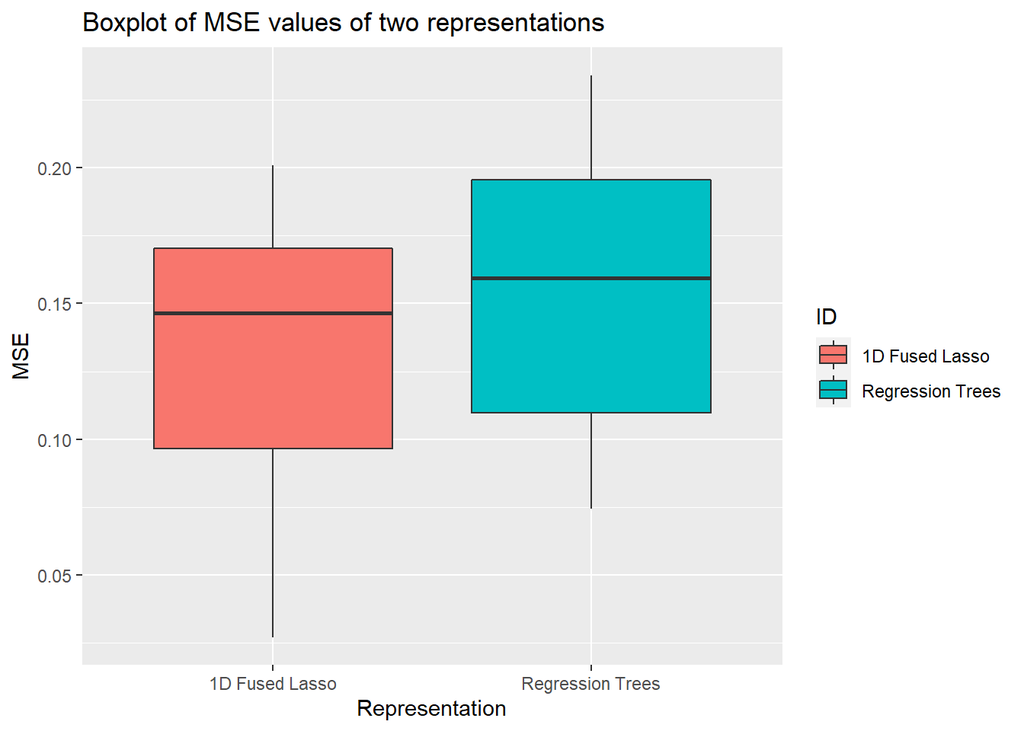

```r
# MSE for the Lasso
fitted_lasso <- as.matrix(lasso[[2]])
real_series <- as.matrix(cbf[,-c("ID","Class")])
squared_errors_lasso  <- (fitted_lasso - real_series)^2
mse_lasso <- rowSums(squared_errors_lasso)/128

# MSE for the Regression Trees
fitted_trees <- as.matrix(regtree[[2]])
#real_series <- as.matrix(cbf[,-c("ID","Class")])
squared_errors_trees  <- (fitted_trees - real_series)^2
mse_trees <- rowSums(squared_errors_trees)/128

#Boxplot
ID <- c(rep("1D Fused Lasso",times = 30),rep("Regression Trees",times = 30))
MSE <- c(mse_lasso,mse_trees)
df1 <- data.frame(ID, MSE)

ggplot(df1,aes(y = MSE, fill = ID))+
  geom_boxplot(aes(x = as.factor(ID)))+
  labs(title = 'Boxplot of MSE values of two representations', x = 'Representation')
```

As it can be seen from the boxplot above, 1D Fused Lasso has a lower mean MSE compared to Regression Tree. Also, variance of the MSEs of 1D Fused Lasso is slightly lower than the Regression Trees. Finally, we can see that the both distributions are skewed towards the higher MSE values that is their distribution are do not resemble normal.

# Task 4 - Predictions

In this part, prediction accuracy of the representations on the training set is compared with the prediction accuracy of the raw series. Distance between each time series are calculated using Euclidean Distance three time for raw time series, regression tree representations and 1D Fused Lasso representations. Then, using the distance matrix obtained, each class is classified using a 1-nearest neighbor classifier in which each class is assigned the class of its nearest neighbor.

## Raw Time Series

First, distances between raw time series are calculated. The resulting distance matrix are as follows.

```r
class <- cbf$Class

# Classification Using Raw Series
# 1-NN Classifier Using the Raw Data

raw_data_dist <- dist(as.matrix(cbf[,c(-1,-2)]))
raw_data_dist <- as.matrix(raw_data_dist)
diag(raw_data_dist) <- 1000

head(round(raw_data_dist,2))
```

```
##         1       2       3       4       5       6     7     8     9    10    11
## 1 1000.00    9.45    9.36   13.25   15.84   11.51  8.68 14.20 11.22  8.07  8.82
## 2    9.45 1000.00   11.02   11.64   16.72   12.47  7.51 11.45 10.99  7.84 11.05
## 3    9.36   11.02 1000.00   10.73   17.41    9.42 10.20 12.07 14.89  9.53 11.43
## 4   13.25   11.64   10.73 1000.00   17.79   14.21 11.34 10.33 16.51 11.36 15.09
## 5   15.84   16.72   17.41   17.79 1000.00   16.71 16.45 18.75 13.40 16.53 15.98
## 6   11.51   12.47    9.42   14.21   16.71 1000.00 11.78 14.41 13.97 11.76 11.13
##      12    13    14    15    16    17    18    19    20    21    22    23    24
## 1  9.96 11.33 11.27 15.28  8.35 15.66 14.79 11.07 14.10 17.26 14.16  9.10 12.35
## 2 12.37 13.16 11.35 16.77 10.91 16.72 15.39 12.67 11.80 18.04 14.90 11.64 15.00
## 3 12.25 13.23 15.02 17.55  9.54 17.93 17.16 13.10 12.03 18.95 16.88 11.91 14.46
## 4 16.00 14.49 16.69 17.87 12.68 18.59 17.93 15.22  9.07 18.57 17.90 14.32 15.97
## 5 15.13 11.89 15.14  7.11 15.06  7.35  9.83 10.47 18.35 11.19 10.45 12.49 11.45
## 6 11.56 13.35 14.59 16.82 11.71 16.84 16.79 13.57 14.74 17.49 16.45 12.85 14.52
##      25    26    27    28    29    30
## 1  8.05 10.37 10.09 10.42  9.88  8.22
## 2  9.65 12.16 11.58 12.20 11.21  9.27
## 3  9.24  8.74  9.74  7.76  8.67 11.43
## 4 12.24 11.33 14.56 10.15 11.27 13.77
## 5 15.99 16.80 16.48 17.42 16.35 14.34
## 6 11.24 12.16  8.76 11.66 11.79 12.40
```

Corresponding prediction matrix and the prediction accuracy obtained using the 1-NN classified are as follows.

```r
raw_data_dist_order <- apply(raw_data_dist, 1, order)
closest_raw <- raw_data_dist_order[1,]
predicted_raw <- class[closest_raw]

table(class,predicted_raw)
```

```
##      predicted_raw
## class  1  2  3
##     1  8  0  2
##     2  1 11  0
##     3  2  0  6
```

```r
acc_raw <- sum(class==predicted_raw)/length(predicted_raw)
print(paste('Prediction Accuracy:',acc_raw))
```

```
## [1] "Prediction Accuracy: 0.833333333333333"
```

Prediction accuracy is 83.33%.

## 1D Fused Lasso

First, distances between representations obtained using the 1D Fused Lasso method are calculated. The resulting distance matrix are as follows.

```r
# Classification Using FusedLasso Representation
# 1-NN Classifier Using the FusedLasso Representation

lasso_dist <- dist(as.matrix(fitted_lasso))
lasso_dist <- as.matrix(lasso_dist)
diag(lasso_dist) <- 1000

head(lasso_dist)
```

```
##             1           2           3           4          5           6
## 1 1000.000000    7.652124    7.904467   11.046131   14.14541    8.825189
## 2    7.652124 1000.000000    9.450797    9.945549   14.88108   10.029359
## 3    7.904467    9.450797 1000.000000    7.996591   15.95561    6.349780
## 4   11.046131    9.945549    7.996591 1000.000000   15.75246   11.167133
## 5   14.145414   14.881082   15.955610   15.752458 1000.00000   14.414955
## 6    8.825189   10.029359    6.349780   11.167133   14.41496 1000.000000
##           7         8         9        10        11        12        13
## 1  6.072295 12.348304  8.905342  5.947014  6.120088  7.299113  9.813524
## 2  4.636434  9.267879  8.668917  5.998824  8.808765  9.504340 11.706301
## 3  8.579064  9.901796 13.333334  8.505677  9.400784 10.137615 11.535326
## 4  9.269594  6.689503 14.585869  9.658694 12.488360 13.019649 12.333096
## 5 14.418326 16.615062 11.250260 15.151991 13.785654 13.021715  9.247196
## 6  9.347339 11.569091 11.961211  9.477190  7.984414  8.400904 11.301458
##          14        15        16        17        18        19        20
```

[output cut: 20 more lines]

Corresponding prediction matrix and the prediction accuracy obtained using the 1-NN classified are as follows.

```r
lasso_dist_order <- apply(lasso_dist, 1, order)
closest_lasso <- lasso_dist_order[1,]
predicted_lasso <- class[closest_lasso]

table(class,predicted_lasso)
```

```
##      predicted_lasso
## class  1  2  3
##     1  8  0  2
##     2  0 12  0
##     3  0  0  8
```

```r
acc_lasso <- sum(class==predicted_lasso)/length(predicted_lasso)
print(paste('Prediction Accuracy:',acc_lasso))
```

```
## [1] "Prediction Accuracy: 0.933333333333333"
```

Prediction accuracy is 93.33%.

## Regression Trees

First, distances between representations obtained using the regression trees are calculated. The resulting distance matrix are as follows.

```r
tree_dist <- dist(as.matrix(fitted_trees))
tree_dist <- as.matrix(tree_dist)
diag(tree_dist) <- 1000

head(tree_dist)
```

```
##             1           2           3           4          5           6
## 1 1000.000000    7.907729    8.877449   11.904842   14.55167    9.390976
## 2    7.907729 1000.000000   10.103099   10.889667   15.52645   10.636952
## 3    8.877449   10.103099 1000.000000    8.235741   16.50510    6.654277
## 4   11.904842   10.889667    8.235741 1000.000000   16.45801   11.593783
## 5   14.551669   15.526452   16.505103   16.458008 1000.00000   15.174457
## 6    9.390976   10.636952    6.654277   11.593783   15.17446 1000.000000
##           7         8         9        10        11        12        13
## 1  6.674723 12.940892  9.324024  5.910642  6.535612  7.760869  9.613577
## 2  5.147560 10.057695  8.757671  5.677672  9.408071  9.645177 11.427799
## 3  9.299874 10.096717 13.966105  8.917384 10.047698 10.519914 11.231284
## 4 10.214360  7.444941 15.100479 10.014214 13.298561 13.548214 12.290962
## 5 15.423575 17.515678 11.725486 15.446912 14.671029 13.972484  9.357557
## 6  9.879745 12.279087 12.565208  9.772909  8.736647  9.294536 11.147115
##          14        15        16        17        18        19        20
```

[output cut: 20 more lines]

Corresponding prediction matrix and the prediction accuracy obtained using the 1-NN classified are as follows.

```r
tree_dist_order <- apply(tree_dist, 1, order)
closest_tree <- tree_dist_order[1,]
predicted_tree <- class[closest_tree]

table(class,predicted_tree)
```

```
##      predicted_tree
## class  1  2  3
##     1  8  0  2
##     2  0 12  0
##     3  1  0  7
```

```r
acc_tree <- sum(class==predicted_tree)/length(predicted_tree)
print(paste('Prediction Accuracy:',acc_tree))
```

```
## [1] "Prediction Accuracy: 0.9"
```

Prediction accuracy is 90.00%.

## Conclusion

In conclusion, prediction accuracy of the both representations, 1D Fused Lasso and Regression Trees, are better than the prediction accuracy obtained using the raw time series. On the other hand, accuracy of the 1D Fused Lasso Method’s accuracy is slightly higher than the accuracy of the Regression Tree Method. However, their accuracy values are very close. Either one of the methods can perform better compared to other method for a given test data.